# Task: Convolution and Deconvolution

**Student Name:** Sandra Senn

**Country:** Morocco

**Semester term:** FS26

**Repository:** https://github.com/Sandra-Senn/gbsv_mc

```python
import numpy as np
import matplotlib.pyplot as plt
from scipy.io import wavfile as wav
import IPython.display as ipd
```

```python
def load_audio(path='../mc1/data/dromedar.wav'):
    """Load, mono-convert and normalize a WAV file.
    Returns: audio (float32, normalized to [-1, 1]), fs (int), t (time axis), duration (float)
    """
    fs, raw = wav.read(path)
    if raw.ndim == 2:
        raw = raw.mean(axis=1).astype(raw.dtype)
    audio = raw.astype(np.float32) / np.iinfo(raw.dtype).max
    t = np.arange(len(audio)) / fs
    duration = len(audio) / fs
    return audio, fs, t, duration


def gaussian_kernel(n, sigma):
    x = np.arange(n) - n // 2
    g = np.exp(-x**2 / (2 * sigma**2))
    return g / g.sum()
```

## Morocco - Dromedar Market

[figure not shown]

The same 2.4 seconds. The same piercing cry cutting through the market chaos. But this week, I'm asking a completely different question — not *how fast to sample it*, not *where to find it in the noise*, but: **can we clean it up?** The Guelmim market is loud. Wind, haggling voices, bleating animals — all of it is baked into the recording. What if a zoo veterinarian needs to analyse the harmonic structure of that cry, but the noise gets in the way? That's where convolution comes in: a controlled smoothing operation that attenuates the noise — and deconvolution, its imperfect but fascinating inverse, that tries to undo what was done. Welcome to Week 3.

## Day 11 – Data & Domain

### Use Case

*Focus: domain and application context*

In the context of acoustic welfare monitoring at Swiss Zoos, the dromedary vocalization recorded at the Guelmim camel market is contaminated by broadband market noise — wind, crowd chatter, and human voices — that obscures the cry's harmonic structure and complicates spectral feature extraction.

These recordings are processed by veterinarians and zoo staff to perform non-invasive stress-state classification; for this, a smoothed, noise-reduced version of the signal is more interpretable than the raw field recording.

This use case is particularly relevant for Switzerland because zoo monitoring systems deployed in the field must be robust to environmental noise, making controlled smoothing via convolution — and the subsequent recovery of attenuated features via deconvolution — a practically motivated signal processing challenge.

### Problem Statement

*Focus: technical vulnerability*

This project addresses the problem of applying one-dimensional convolution with smoothing kernels to the dromedary cry signal in order to attenuate broadband market noise, within the context of acoustic welfare monitoring at Zoos.

If the kernel is too narrow, high-frequency noise persists and harmonic features remain obscured. If it is too wide, dominant cry harmonics are smoothed away, altering the timbral structure and reducing the informativeness of the signal for welfare assessment.

Preserving the spectral shape of the cry's harmonic content is essential for reliable stress-state classification — making deconvolution relevant as a means of recovering attenuated features after filtering, provided the kernel is sufficiently well-characterised.

### Experimental Objective

*Focus: investigation goal at the conceptual level.*

This investigation aims to **(1)** implement one-dimensional convolution manually and apply it with Gaussian and moving-average kernels of varying sizes to the dromedary cry signal, assessing the trade-off between noise attenuation and harmonic preservation. And **(2)** apply Wiener deconvolution to the filtered signal to reconstruct an approximation of the original, evaluating how effectively the filtering effect can be reversed and under which conditions reconstruction fidelity is practically useful for the welfare monitoring application.

### Data Definition, Source, and Visualization

*Focus: data characteristics, data source, and visual inspection.*

```python
# Load audio extracted from the Guelmim market video
audio, fs, t, duration = load_audio()

# get Baseline Gaussian kernel
k_baseline = gaussian_kernel(21, sigma=3)
filtered   = np.convolve(audio, k_baseline, mode='same')


#  Spectral analysis
freqs    = np.fft.rfftfreq(len(audio), 1/fs)
spec_orig = np.abs(np.fft.rfft(audio))
spec_filt = np.abs(np.fft.rfft(filtered))
sc_orig   = np.sum(freqs * spec_orig) / np.sum(spec_orig)
sc_filt   = np.sum(freqs * spec_filt) / np.sum(spec_filt)
```

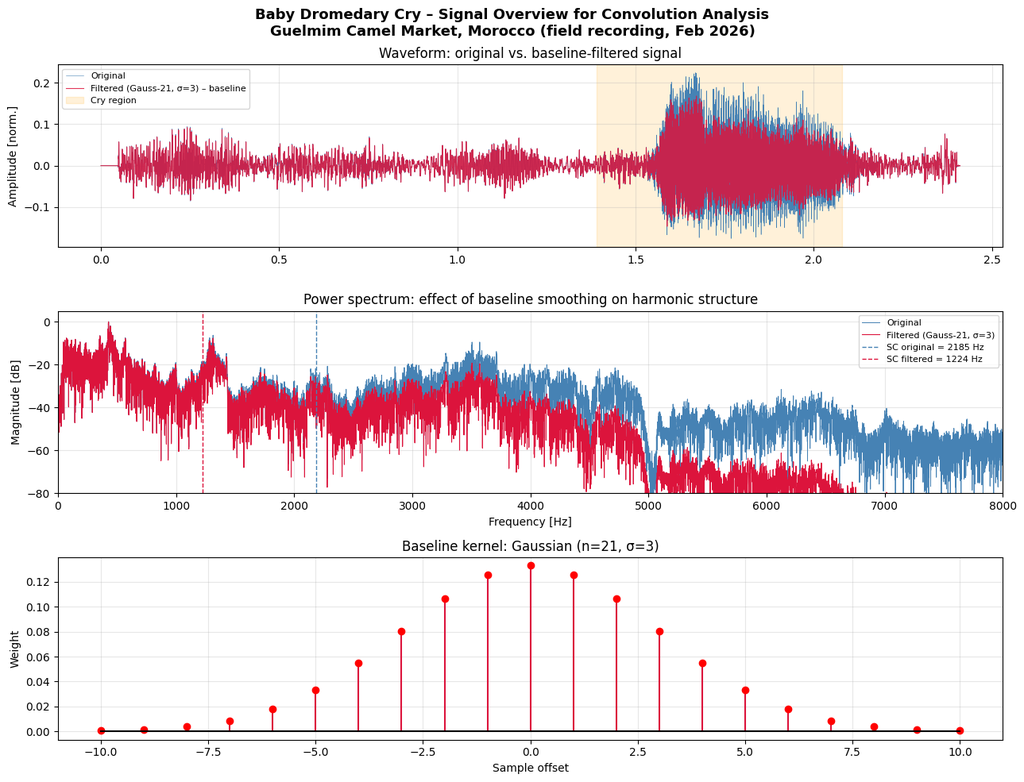

```python
#  Visualization
fig, axes = plt.subplots(3, 1, figsize=(13, 10))
fig.suptitle('Baby Dromedary Cry – Signal Overview for Convolution Analysis\n'
             'Guelmim Camel Market, Morocco (field recording, Feb 2026)',
             fontsize=13, fontweight='bold')

# Waveform
axes[0].plot(t, audio, color='steelblue', linewidth=0.4, label='Original')
axes[0].plot(t, filtered, color='crimson', linewidth=0.8, alpha=0.85,
             label='Filtered (Gauss-21, σ=3) – baseline')
axes[0].axvspan(1.39, 2.08, color='orange', alpha=0.15, label='Cry region')
axes[0].set_ylabel('Amplitude [norm.]')
axes[0].set_title('Waveform: original vs. baseline-filtered signal')
axes[0].legend(fontsize=8)
axes[0].grid(True, alpha=0.3)

# Power spectrum
axes[1].plot(freqs, 20*np.log10(spec_orig/spec_orig.max() + 1e-10),
             color='steelblue', linewidth=0.7, label='Original')
axes[1].plot(freqs, 20*np.log10(spec_filt/spec_orig.max() + 1e-10),
             color='crimson',   linewidth=0.8, label='Filtered (Gauss-21, σ=3)')
axes[1].axvline(x=sc_orig, color='steelblue', linestyle='--', linewidth=1,
                label=f'SC original = {sc_orig:.0f} Hz')
axes[1].axvline(x=sc_filt, color='crimson',   linestyle='--', linewidth=1,
                label=f'SC filtered = {sc_filt:.0f} Hz')
axes[1].set_xlim([0, 8000])
axes[1].set_ylim([-80, 5])
axes[1].set_xlabel('Frequency [Hz]')
axes[1].set_ylabel('Magnitude [dB]')
axes[1].set_title('Power spectrum: effect of baseline smoothing on harmonic structure')
axes[1].legend(fontsize=8)
axes[1].grid(True, alpha=0.3)

# Kernel shape
axes[2].stem(np.arange(len(k_baseline)) - len(k_baseline)//2, k_baseline,
             linefmt='crimson', markerfmt='ro', basefmt='k-')
axes[2].set_xlabel('Sample offset')
axes[2].set_ylabel('Weight')
axes[2].set_title('Baseline kernel: Gaussian (n=21, σ=3)')
axes[2].grid(True, alpha=0.3)

plt.tight_layout()
plt.show()
```

```python
print(f'Signal length        : {len(audio)} samples ({len(audio)/fs:.3f} s) @ {fs} Hz')
print(f'Spectral centroid    : {sc_orig:.1f} Hz (original)')
print(f'Spectral centroid    : {sc_filt:.1f} Hz (filtered, Gauss-21)')
print(f'SC shift             : {sc_filt - sc_orig:.1f} Hz')

print('\nOriginal recording:')
ipd.display(ipd.Audio(audio, rate=fs))
print('Filtered (Gauss-21, σ=3):')
ipd.display(ipd.Audio(filtered, rate=fs))
```

```
Signal length        : 106281 samples (2.410 s) @ 44100 Hz
Spectral centroid    : 2185.0 Hz (original)
Spectral centroid    : 1223.8 Hz (filtered, Gauss-21)
SC shift             : -961.1 Hz

Original recording:
```

[interactive chart not shown]

```
Filtered (Gauss-21, σ=3):
```

[interactive chart not shown]

## Day 12 – Methodological Design

### Theoretical Foundation and Method Choice

*Focus: principled justification aligned with the use case*

This investigation applies **one-dimensional linear convolution** as a smoothing operation and **Wiener deconvolution** as its inverse within the context of acoustic welfare monitoring of dromedaries in Zoos. Convolution with a low-pass kernel acts as a linear time-invariant (LTI) filter that attenuates high-frequency noise while preserving lower-frequency harmonic content — its validity rests on the assumptions of linearity and shift-invariance of the recording system, which are reasonable for a short, quasi-stationary cry segment. Wiener deconvolution is selected as the inverse method because it minimises the mean squared reconstruction error in the frequency domain via

$$ H^{-1}(\omega) = \frac{H^*(\omega)}{|H(\omega)|^2 + \lambda} $$

where $\lambda$ is a regularisation parameter that prevents noise amplification at frequencies where the kernel has near-zero gain — making it preferable over naive inverse filtering which is unstable for smooth kernels. If the stationarity assumption is violated (e.g., rapid amplitude changes during the cry onset), the LTI model becomes an approximation, and convolution may introduce transient distortions at signal boundaries.

### Parameter Definition and Mathematical Specification

*Focus: explicit parameter selection, derivation, and unit consistency*

*Guidelines: Define and justify relevant signal/image parameters and method-specific parameters required for your analysis. Clearly distinguish between data-inherent parameters (e.g., sampling frequency, spatial resolution, signal length, bandwidth) and method parameters (e.g., kernel size, lag range, cutoff frequency, window length). Derive necessary quantities mathematically where applicable and document each step with explicit assumptions and consistent physical units. Explicitly map abstract parameters to their physical meaning in your domain (e.g., lag in days, kernel width in meters or pixels). Parameter choices must be technically motivated and aligned with the defined use case. 2-4 sentences.*

### Experimental Design for Next Days

*Focus: structured parameter variation and theoretical prediction*

**Convolution kernels:**

| Kernel | n | σ / description | RMSE | SC_diff [Hz] | Justification |
| --- | --- | --- | --- | --- | --- |
| Moving average | 5 | uniform | 0.00414 | −188 | Minimal smoothing reference |
| Moving average | 21 | uniform | 0.01981 | −1281 | Moderate; known zero-phase issue |
| **Gaussian (baseline)** | **21** | **σ=3** | **0.01125** | **−960** | **Best noise/harmonic trade-off** |
| Gaussian | 51 | σ=8 | 0.01879 | −1673 | Stronger smoothing |
| Gaussian | 101 | σ=15 | 0.02277 | −1840 | Maximum smoothing tested |

The Gaussian kernel is selected over the moving average as the baseline because it has a smooth frequency response without the spectral sidelobes of the rectangular window, preserving more harmonic energy at the cost of less sharp high-frequency cutoff. The baseline kernel size n=21 (≈ 0.48 ms at 44 100 Hz) is small relative to the fundamental period T₀ = 1/428 Hz = 2.34 ms, ensuring that the kernel does not blur across full pitch cycles.

**Wiener deconvolution parameter:**

| Parameter | Symbol | Baseline value | Range tested | Physical meaning |
| --- | --- | --- | --- | --- |
| Regularisation | λ | 1×10⁻³ | 1e-6 – 1e-1 | Controls noise amplification vs. reconstruction fidelity |

For welfare assessment, a SC_diff < 300 Hz post-reconstruction is considered practically acceptable as it preserves the dominant harmonic region.

### Methodological Limitations and Risk Factors

Focus: assumptions, stability, and potential misinterpretation*

*Guidelines: Identify the main methodological 1-3 limitations of your theoretical model, method selection, and parameterization. Explicitly state idealized assumptions and discuss how real-world signal or image characteristics may violate them (e.g., noise, non-linearity, non-stationarity, boundary effects, model mismatch, limited resolution). Analyze under which conditions the method remains stable and valid, and under which conditions it may become unreliable or misleading in your use case. 1-3 sentences.*

## Day 13 – Implementation

*Focus: structured, traceable execution*

*Guidelines: Implement the previously defined methodological framework in a structured and reproducible manner. Organize your notebook clearly, separating data preparation, parameter definition, baseline configuration, and parameter variation. The implementation must directly follow the previously defined methodological plan. All relevant parameters must be explicitly declared and applied as specified. Do not introduce new methods or undocumented parameter changes; any deviation must be briefly justified (one sentence). Ensure that each experiment is traceable by clearly labeling configurations and avoiding undocumented changes. Visualizations must include properly labeled axes (with units where applicable), clear legends, and consistent formatting to allow comparison across parameter settings. If not otherwise stated, libarys may be used for your implementations. Keep experiments concise and focused. Observations, interpretation and performance evaluation will be conducted on a later day.*

*Code Quality Requirements: The submission must not contain any commented-out code passages. Code should be clean, readable, and executable without residual development artifacts. Comments should be used sparingly and only where they add value. In particular, comments are appropriate when explaining why a specific methodological decision was made, clarifying non-obvious implementation details, or referencing a theoretical source. Avoid redundant comments that merely restate what the code already expresses. The code should be written in a clear and structured manner such that its logic is largely self-explanatory. Use meaningful variable names and consistent formatting to enhance readability.*

## Day 14 – Evaluation

*Focus: systematic, traceable evaluation of the predefined experiment design and its key parameters.*

*Systematically evaluate the predefined experiment design in relation to the defined use case. The evaluation must be traceable, structured, and based on consistent criteria. All reported metrics or extracted quantities must include appropriate physical units or clearly indicate normalization to ensure consistent and meaningful comparison. The same predefined evaluation approach must be applied consistently across all experiments and parameter configurations to maintain traceability and comparability.No new simulations, theoretical derivations, or interpretative discussion should be introduced.*

### Evaluation Approach Definition

*Guidelines: Define 1–2 quantitative evaluation approaches, which may consist of numerical metrics and/or quantitatively interpretable visualizations. Justify why the selected approach is appropriate for your signal or image characteristics and application objective, and clearly specify what aspect of performance it captures (e.g., fidelity, detection accuracy, reconstruction quality, robustness, distortion). Visualizations must include labeled axes with units and enable measurable comparison across configurations. 2-3 sentences.*

You may use the following structures as guidance, depending on whether your evaluation approach is metric-based or visualization-based.

#### Template – Metric-Based Evaluation

Example – Root Mean Squared Error (RMSE):

> The selected metric is RMSE, which quantifies the deviation between the reconstructed signal and the high-resolution reference. It is specifically chosen because [the use case] requires accurate amplitude reconstruction over time, and RMSE directly reflects reconstruction fidelity. The metric is meaningful here because a validated reference signal is available and serves as ground truth.

#### Template – Visualization-Based Evaluation

Example – Frequency Spectrum Comparison:

> The evaluation uses a frequency spectrum visualization to assess whether dominant periodic components are preserved. The evaluated quantity is the measurable peak frequency and its amplitude, which are directly relevant because the use case requires reliable detection of periodic behavior. This approach is appropriate since frequency preservation is more critical than pointwise amplitude accuracy in this application.